# 의학통계방법론 1조 5주차 과제

김재혁, 정지현

2022-04-07

```r
getwd()
```

```
## [1] "C:/git_blog/study/data/ch11"
```

```r
library(readxl)
library(dplyr)
library(kableExtra)
library(MBESS)
library(DescTools)
library(PMCMRplus)
```

**엑셀파일불러오기**

```r
#모든 시트를 하나의 리스트로 불러오는 함수
read_excel_allsheets <- function(file, tibble = FALSE) {
  sheets <- readxl::excel_sheets(file)
  x <- lapply(sheets, function(X) readxl::read_excel(file, sheet = X))
  if(!tibble) x <- lapply(x, as.data.frame)
  names(x) <- sheets
  x
}
```

## 0.1 11장

**11장 연습문제 불러오기**

```r
#data_chap11에 연습문제 7장 모든 문제 저장
data_chap11 <- read_excel_allsheets("data_chap11.xls")

#연습문제 각각 데이터 생성
for (x in 1:length(data_chap11)){
  assign(paste0('ex11_',c(1,10))[x],data_chap11[x])
  }

#연습문제 데이터 형식을 리스트에서 데이터프레임으로 변환
for (x in 1:length(data_chap11)){
  assign(paste0('ex11_',c(1,10))[x],data.frame(data_chap11[x]))
  }
```

## 0.2 EXAMPLE 11.1

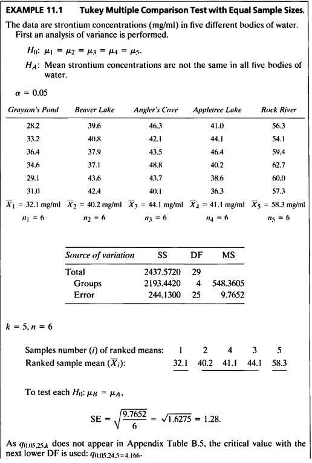

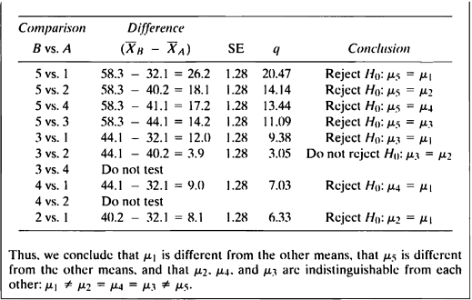

```r
#데이터셋
ex11_1%>%
  kbl(caption = "Dataset",escape=F) %>%
  kable_styling(bootstrap_options = c("striped", "hover", "condensed", "responsive"))
```

Dataset

| exam11_1.pond | exam11_1.strontium |
| --- | --- |
| 1 | 28.2 |
| 1 | 33.2 |
| 1 | 36.4 |
| 1 | 34.6 |
| 1 | 29.1 |
| 1 | 31.0 |
| 2 | 39.6 |
| 2 | 40.8 |
| 2 | 37.9 |
| 2 | 37.1 |
| 2 | 43.6 |
| 2 | 42.4 |
| 3 | 46.3 |
| 3 | 42.1 |
| 3 | 43.5 |
| 3 | 48.8 |
| 3 | 43.7 |
| 3 | 40.1 |
| 4 | 41.0 |
| 4 | 44.1 |
| 4 | 46.4 |
| 4 | 40.2 |
| 4 | 38.6 |
| 4 | 36.3 |
| 5 | 56.3 |
| 5 | 54.1 |
| 5 | 59.4 |
| 5 | 62.7 |
| 5 | 60.0 |
| 5 | 57.3 |

- 해당 데이터는 5가지 다른 수역의 strontium 농도(mg/ml) 데이터이다.
- 분산분석을 실시 후 그룹간 차이가 있다는 결론이 났을 때, 어느 그룹간 평균이 차이가 있는지 사후검정을 통해 살펴볼 것이다.
- 이 문제에서는 튜키 검정을 통해 사후검정을 시행해 보았다.

$$\begin{aligned}
H_0 &: \mu_1=\mu_2=\mu_3=\mu_4=\mu_5 \\
H_1 &: Mean \ strontium \ concentrations \ are \ not \ the \ same \
in \ all \ five \ bodies \ of \ water
\end{aligned}$$

- 우선 분산분석의 가정인 independence, homoscedasticity, normality 살펴보자.

> Independence test with residuals

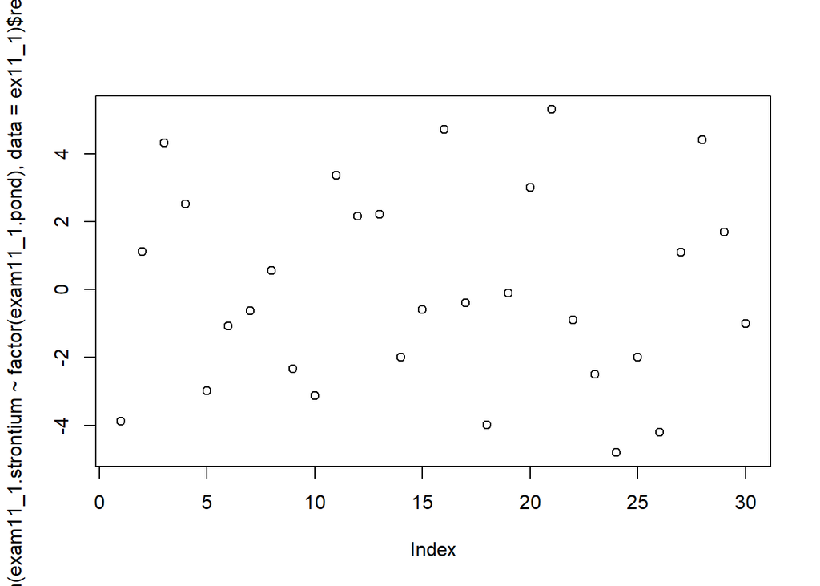

```r
plot(glm(exam11_1.strontium~factor(exam11_1.pond),data=ex11_1)$residual)
```

- 잔차에 대한 scatter plot을 봤을 때 골고루 분포 되어 있으므로 독립성을 만족한다 할 수 있다.

> Normality test with shapiro test

```r
library(rstatix)
exam11_1.normal<-ex11_1 %>%
  group_by(exam11_1.pond) %>%
  shapiro_test(exam11_1.strontium)

exam11_1.normal %>%
  kbl(caption = "Example11_1 : 정규성 가정") %>%
  kable_styling()
```

Example11_1 : 정규성 가정

| exam11_1.pond | variable | statistic | p |
| --- | --- | --- | --- |
| 1 | exam11_1.strontium | 0.9567420 | 0.7943129 |
| 2 | exam11_1.strontium | 0.9616302 | 0.8322126 |
| 3 | exam11_1.strontium | 0.9718105 | 0.9043687 |
| 4 | exam11_1.strontium | 0.9783967 | 0.9433162 |
| 5 | exam11_1.strontium | 0.9893713 | 0.9875855 |

- 각 수역에서 strontium 농도가 6번씩 측정이 되어 전체 표본의 수는 30이다.
- 표본의 크기가 크지 않으므로 정규성 검정으로 Shapiro-Wilk test를 시행하였으며,  
  p-value는 각 수역별로 0.7943, 0.8322, 0.9044, 0.9433, 0.9876으로 모두 유의수준 5%하에 귀무가설을 기각할 수 없다.
- 따라서 정규성 가정을 만족한다는 귀무가설을 기각할 수 없으므로 정규성 가정을 만족한다고 볼 것이다.

> Homoscedasticity test with bartlett test

```r
bartlett.test(ex11_1$exam11_1.strontium,ex11_1$exam11_1.pond)
```

```
##
##  Bartlett test of homogeneity of variances
##
## data:  ex11_1$exam11_1.strontium and ex11_1$exam11_1.pond
## Bartlett's K-squared = 0.63895, df = 4, p-value = 0.9586
```

- 정규성 가정이 모두 만족되었으므로 등분산 검정으로 Bartlett’s Test를 시행하였다.
- p-value는 0.9586으로 유의수준 5%하에 모분산이 서로 동일하다는 귀무가설을 기각하지 못한다.
- 즉, 유의수준 5%하에 등분산 가정을 만족한다고 볼 것이다.
- 분산분석 가정을 모두 만족하였으므로 일원분산분석을 시행하여 보겠다.

```r
ex11_1.anova<-aov(ex11_1$exam11_1.strontium ~ as.factor(ex11_1$exam11_1.pond))
summary(ex11_1.anova)
```

```
##                                 Df Sum Sq Mean Sq F value   Pr(>F)
## as.factor(ex11_1$exam11_1.pond)  4 2193.4   548.4   56.16 3.95e-12 ***
## Residuals                       25  244.1     9.8
## ---
## Signif. codes:  0 '***' 0.001 '**' 0.01 '*' 0.05 '.' 0.1 ' ' 1
```

- 일원분산분석 결과 p-value는 <.0001으로 유의수준 5%하에 귀무가설을 기각한다.
- 유의수준 5%하에 적어도 하나의 수역에서 strontium 농도의 모평균이 다르다고 볼 수 있는 충분한 증거가 있다.

> tukey 다중비교

```r
ex11_1.tukey <- TukeyHSD(ex11_1.anova,ordered=T)
ex11_1.tukey$`as.factor(ex11_1$exam11_1.pond)` %>%
  kbl(caption = "Example11_1 : Tukey 다중비교") %>%
  kable_styling()
```

Example11_1 : Tukey 다중비교

|  | diff | lwr | upr | p adj |
| --- | --- | --- | --- | --- |
| 2-1 | 8.1500000 | 2.851355 | 13.448645 | 0.0011293 |
| 4-1 | 9.0166667 | 3.718021 | 14.315312 | 0.0003339 |
| 3-1 | 12.0000000 | 6.701355 | 17.298645 | 0.0000053 |
| 5-1 | 26.2166667 | 20.918021 | 31.515312 | 0.0000000 |
| 4-2 | 0.8666667 | -4.431979 | 6.165312 | 0.9884803 |
| 3-2 | 3.8500000 | -1.448645 | 9.148645 | 0.2376217 |
| 5-2 | 18.0666667 | 12.768021 | 23.365312 | 0.0000000 |
| 3-4 | 2.9833333 | -2.315312 | 8.281979 | 0.4791100 |
| 5-4 | 17.2000000 | 11.901355 | 22.498645 | 0.0000000 |
| 5-3 | 14.2166667 | 8.918021 | 19.515312 | 0.0000003 |

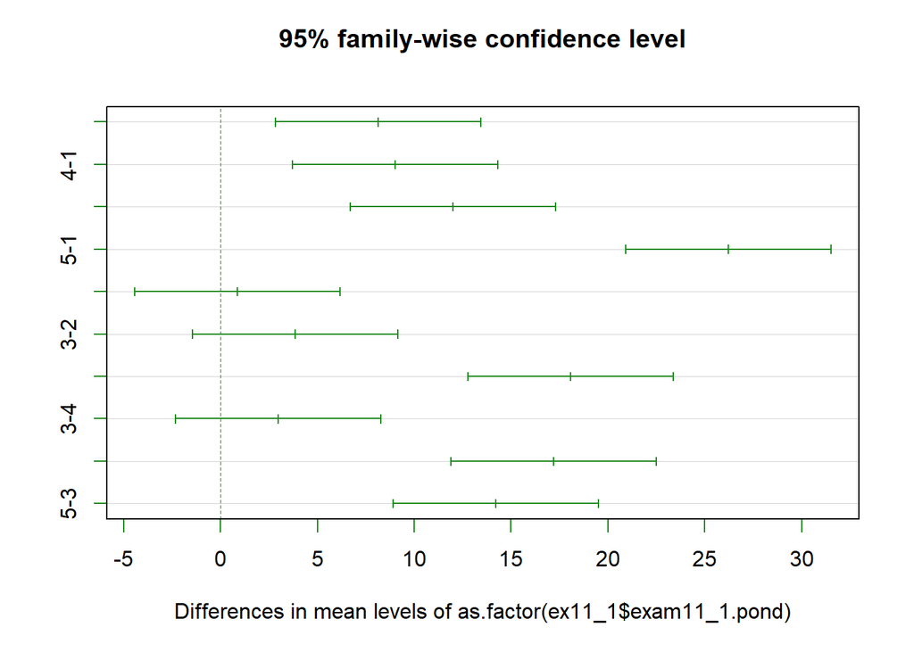

```r
plot(ex11_1.tukey, col="forestgreen")
```

- Appletree Lake-Beaver Lake(4-2), Angler’s Cove-Beaver Lake(3-2), Angler’s Cove-Appletree Lake(3-4) 간의 모평균의 유의한 차이가 없었으며 나머지 수역간에 비교시 유의수준 5% 하에 모평균의 유의한 차이가 있다고 할 수 있다.

## 0.3 EXAMPLE 11.2

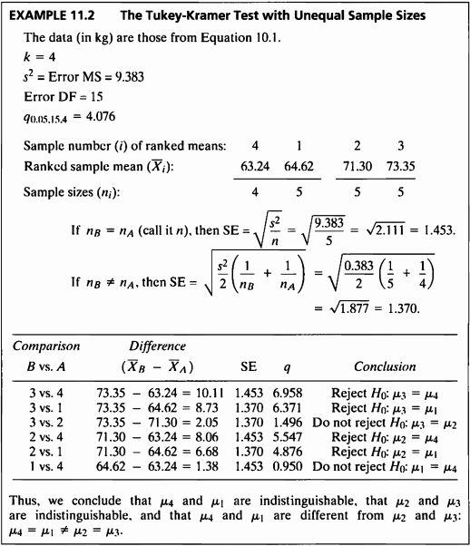

```r
ex11_2 <- read_excel(path = 'C:/git_blog/study/data/ch10/data_chap10.xls',sheet = 'exam10_1')
ex11_2[15,3]=NA
ex11_2<-na.omit(ex11_2)
```

- 독립성, 정규성, 등분산성 가정을 만족함을 Example 10.1에서 이미 확인하였으므로 생략하겠다.

```r
ex11_2.anova <- aov(ex11_2$weight ~ as.factor(ex11_2$diet))
ex11_2.tukey <- TukeyHSD(ex11_2.anova,ordered=T)
ex11_2.tukey$`as.factor(ex11_2$diet)` %>%
  kbl(caption = "Example11_2 : Tukey 다중비교") %>%
  kable_styling()
```

Example11_2 : Tukey 다중비교

|  | diff | lwr | upr | p adj |
| --- | --- | --- | --- | --- |
| 1-4 | 1.38 | -4.203737 | 6.963737 | 0.8906642 |
| 2-4 | 8.06 | 2.476263 | 13.643737 | 0.0041505 |
| 3-4 | 10.11 | 4.187553 | 16.032447 | 0.0009497 |
| 2-1 | 6.68 | 1.096263 | 12.263737 | 0.0168421 |
| 3-1 | 8.73 | 2.807553 | 14.652447 | 0.0034914 |
| 3-2 | 2.05 | -3.872447 | 7.972447 | 0.7530266 |

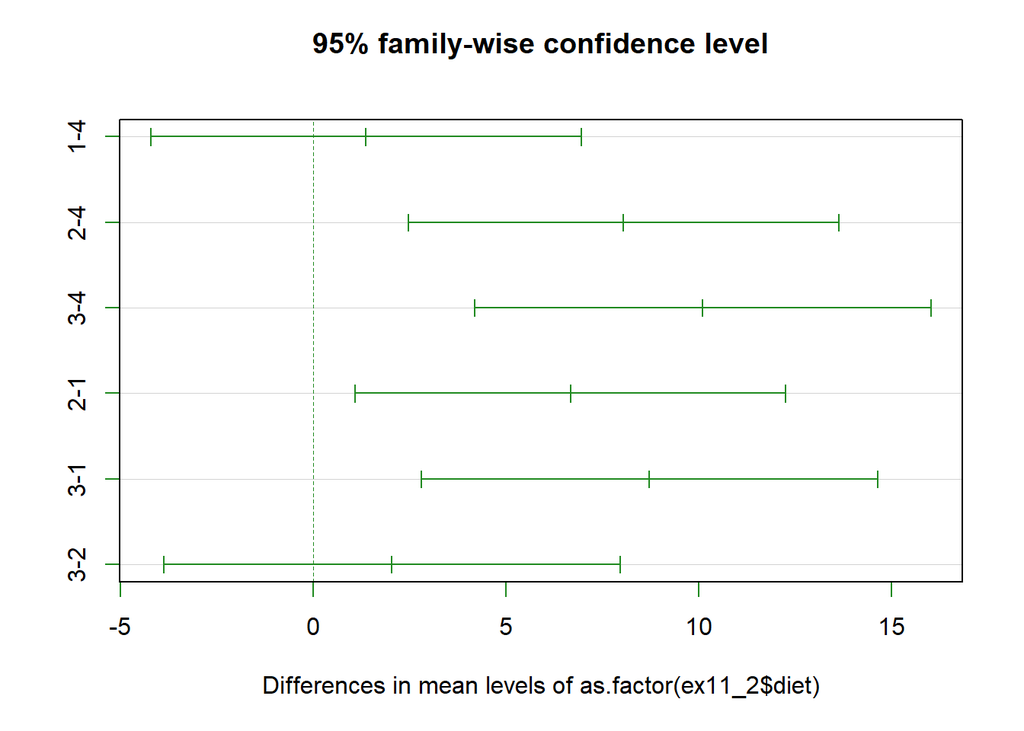

```r
plot(ex11_2.tukey, col = "forestgreen")
```

- Feed1-Feed4(1-4), Feed3-Feed2(3-2) 간의 모평균의 유의한 차이가 없었으며 나머지 사료간의 비교시 유의수준 5% 하에 모평균의 유의한 차이가 있다고 할 수 있다.

## 0.4 EXAMPLE 11.3

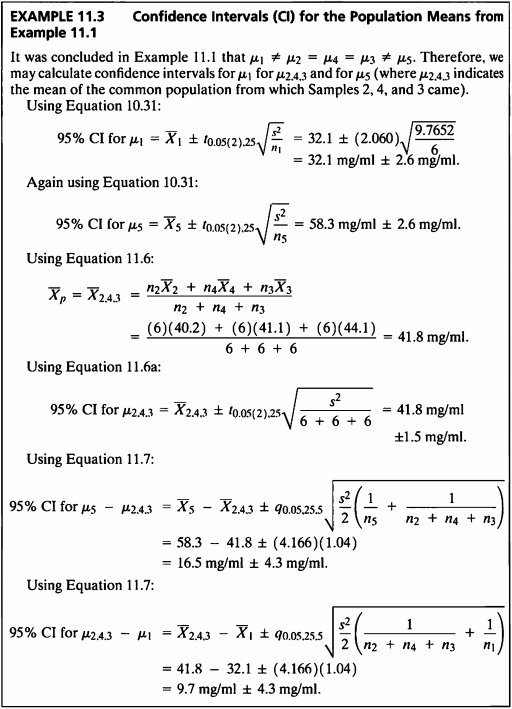

- 이 예제는 Example 11.1 데이터를 사용하여 모평균에 대한 신뢰구간을 구해본다.

```r
library(MBESS)
exam11_1.mean<-aggregate(ex11_1$exam11_1.strontium, by=list(ex11_1$exam11_1.pond), mean)
exam11_1.n <- aggregate(ex11_1$exam11_1.strontium, by=list(ex11_1$exam11_1.pond), length)

ci <- ci.c(means=exam11_1.mean$x, s.anova=sqrt(9.7652),c.weights=c(-3/3,1/3,1/3,1/3,0), n=exam11_1.n$x, N=sum(exam11_1.n$x), conf.level= .95)
data.frame(ci)%>%
  kbl(caption = "CI for the Population Means from ex11_1",escape=F) %>%
  kable_styling(bootstrap_options = c("striped", "hover", "condensed", "responsive"))
```

CI for the Population Means from ex11_1

| Lower.Conf.Limit.Contrast | Contrast | Upper.Conf.Limit.Contrast |
| --- | --- | --- |
| 6.688301 | 9.722222 | 12.75614 |

- 그룹2,4,3과 그룹1의 모평균 차이의 95% 신뢰구간은 (6.69, 12.76)으로 계산되었다.

```r
ci <- ci.c(means=exam11_1.mean$x, s.anova=sqrt(9.7652),c.weights=c(0,-1/3,-1/3,-1/3,1), n=exam11_1.n$x, N=sum(exam11_1.n$x), conf.level= .95)
data.frame(ci)%>%
  kbl(caption = "CI for the Population Means from ex11_1",escape=F) %>%
  kable_styling(bootstrap_options = c("striped", "hover", "condensed", "responsive"))
```

CI for the Population Means from ex11_1

| Lower.Conf.Limit.Contrast | Contrast | Upper.Conf.Limit.Contrast |
| --- | --- | --- |
| 13.46052 | 16.49444 | 19.52837 |

- 그룹5의 모평균과 그룹2,4,3의 모평균의 차의 95% 신뢰구간은 (13.46, 19.53)으로 계산되었다.

## 0.5 EXAMPLE 11.4

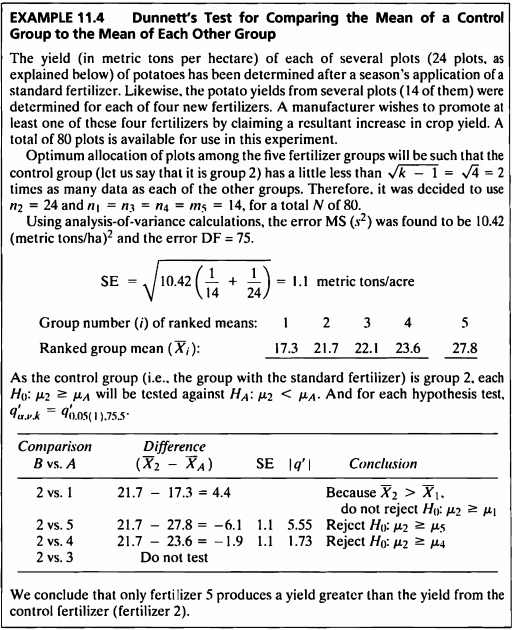

- 해당 데이터는 5가지 비료에 따른 감자 수확량을 mean과 size로 기록한 데이터이다.

```r
mean=c(17.3,21.7,22.1,23.6,27.8)
size= c(14,24,14,14,14)
group=c(1,2,3,4,5)
ex11_4= data.frame(group,mean,size)
ex11_4%>%
  kbl(caption = "Dataset") %>%
  kable_styling(bootstrap_options = c("striped", "hover", "condensed", "responsive"))
```

Dataset

| group | mean | size |
| --- | --- | --- |
| 1 | 17.3 | 14 |
| 2 | 21.7 | 24 |
| 3 | 22.1 | 14 |
| 4 | 23.6 | 14 |
| 5 | 27.8 | 14 |

$$\begin{aligned}
H_0 &: \mu_2 \ge \mu_A \\
H_1 &: \mu_2 < \mu_A
\end{aligned}$$

> Dunnett’s test

```r
k=5
group_index = c(1, 2, 3, 4, 5)
group_n = c(14, 24, 14, 14, 14)
group_mean=c(17.3, 21.7, 22.1, 23.6, 27.8)
N = sum(group_n);
s2 = 10.42;
errorDF=N-k;
se_value = round(sqrt(s2*(1/group_n[1]+1/group_n[2])), 1);
SE = rep(se_value, k)
Difference = rep(group_mean[2], k) - group_mean;
q_prime = abs(round(Difference/se_value, 2));
control = rep(2,k);

exam11_4<-cbind("control"=control, "group_index"=group_index, "Difference"=Difference, "SE"=SE, "q_prime"=q_prime)
exam11_4 %>%
  kbl(caption = "Example11_4 : dunnett") %>%
  kable_styling()
```

Example11_4 : dunnett

| control | group_index | Difference | SE | q_prime |
| --- | --- | --- | --- | --- |
| 2 | 1 | 4.4 | 1.1 | 4.00 |
| 2 | 2 | 0.0 | 1.1 | 0.00 |
| 2 | 3 | -0.4 | 1.1 | 0.36 |
| 2 | 4 | -1.9 | 1.1 | 1.73 |
| 2 | 5 | -6.1 | 1.1 | 5.55 |

- 비료 2과 1를 비교한 결과, 표본 평균의 차이가 양수이므로 귀무가설을 기각할 수 없다.
- 이와 달리 비료 2와 비료 4,5 각각 비교한 결과 표본 평균의 차이가 음수이므로 귀무가설을 기각한다.
- 즉, 기존 2번 비료 보다 새로운 4번 5번 비료를 사용할 때, 감자 수확량의 모평균이 더 크다고 할 수 있다.

$\bar{X}_{2}>\bar{X}_{1}$ 이므로 귀무가설 $H_{0} : \mu_{2} \geq \mu_{A}$을 기각할 수 없다.  
- 그룹2와 그룹5를 비교하면 $|q'|=5.55$가 기각역보다 크므로 귀무가설을 기각한다.  
- 즉, 유의수준 5%하에서 그룹2의 모평균이 그룹5의 모평균보다 작다고 말할 수 있다.  
- 그룹2와 그룹4를 비교하면 $|q'|=1.73$이 기각역보다 크므로 귀무가설을 기각한다.  
- 즉, 유의수준 5%하에서 그룹2의 모평균이 그룹5의 모평균보다 작다고 말할 수 있다.

## 0.6 EXAMPLE 11.5

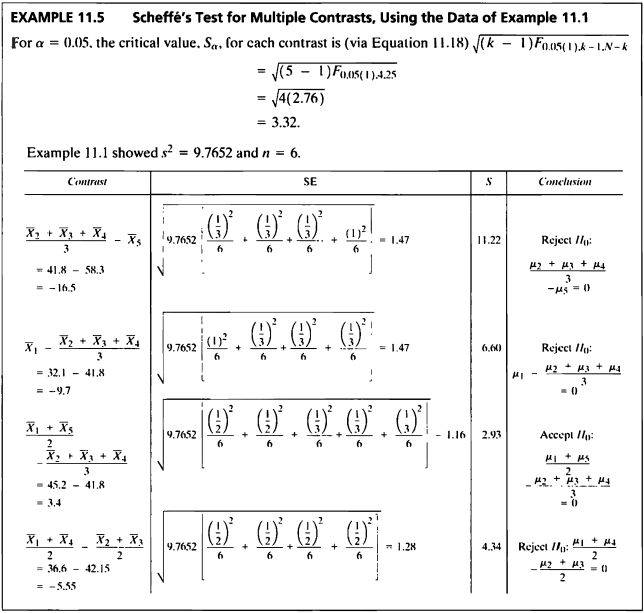

```r
contrast= matrix(c(0, 1/3, 1/3, 1/3, -1,
                   1, -1/3, -1/3, -1/3, 0,
                   1/2, -1/3, -1/3, -1/3, 1/2,
                   1/2, -1/2, -1/2, 1/2, 0), ncol=4)
library(DescTools)
ex11.6<-ScheffeTest(ex11_1.anova, contrasts=contrast)
ex11.6$`as.factor(ex11_1$exam11_1.pond)` %>%
  kbl(caption = "Example 11.5 & 11.6: SCHEFFE") %>%
  kable_styling()
```

Example 11.5 & 11.6: SCHEFFE

|  | diff | lwr.ci | upr.ci | pval |
| --- | --- | --- | --- | --- |
| 2,3,4-5 | -16.494444 | -21.3879194 | -11.600969 | 0.0000000 |
| 1-2,3,4 | -9.722222 | -14.6156972 | -4.828747 | 0.0000299 |
| 1,5-2,3,4 | 3.386111 | -0.4825205 | 7.254743 | 0.1090539 |
| 1,4-2,3 | -5.566667 | -9.8045403 | -1.328793 | 0.0054032 |

- 검정 결과 그룹 1,5와 그룹 2,3,4 외에 다른 경우는 유의수준 5%하에 귀무가설을 기각할 충분한 근거를 가지고 있다.

## 0.7 EXAMPLE 11.6

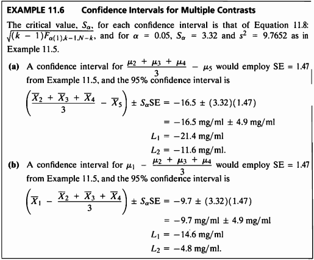

EXAMPLE 11.5 문제의 신뢰구간을 구해본다.

```r
ex11.6$`as.factor(ex11_1$exam11_1.pond)` %>%
  kbl(caption = "Example 11.5 & 11.6: SCHEFFE") %>%
  kable_styling()
```

Example 11.5 & 11.6: SCHEFFE

|  | diff | lwr.ci | upr.ci | pval |
| --- | --- | --- | --- | --- |
| 2,3,4-5 | -16.494444 | -21.3879194 | -11.600969 | 0.0000000 |
| 1-2,3,4 | -9.722222 | -14.6156972 | -4.828747 | 0.0000299 |
| 1,5-2,3,4 | 3.386111 | -0.4825205 | 7.254743 | 0.1090539 |
| 1,4-2,3 | -5.566667 | -9.8045403 | -1.328793 | 0.0054032 |

- 그룹 (2,3,4)와 그룹 5에 대한 95% 신뢰구간은 (-21.39, -11.60), 그룹 1과 그룹 (2,3,4)에 대한 95% 신뢰구간은 (-14.62,-4.83)이다.

## 0.8 EXAMPLE 11.7

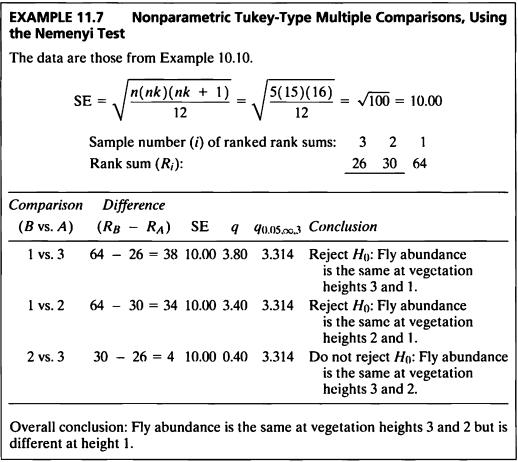

- 이 예제는 EXAMPLE 10.10를 Nemenyi test를 이용하여 비모수적 다중비교를 하는 문제이다.

> Nemenyi test

```r
ex11_7 <- read_excel(path = 'C:/git_blog/study/data/ch10/data_chap10.xls',sheet = 'exam10_10')
library(PMCMRplus)
kwAllPairsNemenyiTest(abundance~factor(layer), data=ex11_7, dist='Tukey')
```

```
##   1     2
## 2 0.043 -
## 3 0.020 0.957
```

- PMCMRplus 패키지의 kwAllPairsNemenyiTest() 함수는 Nemenyi test를 이용하여 비모수적인 다중비교 후 p-value를 나타낸 것이다.
- 그룹 1과 2, 그리고 그룹 1과 3간의 비교에서 p-value는 각각 0.043, 0.020으로 유의수준 5%하에서 귀무가설을 기각하였다.
- 그룹 2와 3간의 비교에서 p-value는 0.957이므로 유의수준 5%하에서 귀무가설을 기각하지 못한다.
- 즉, 파리는 2번 식물의 layer와 3번 식물의 layer에서 같지만 1번 식물의 layer에서는 다르다고 할 수 있다.

## 0.9 EXAMPLE 11.8

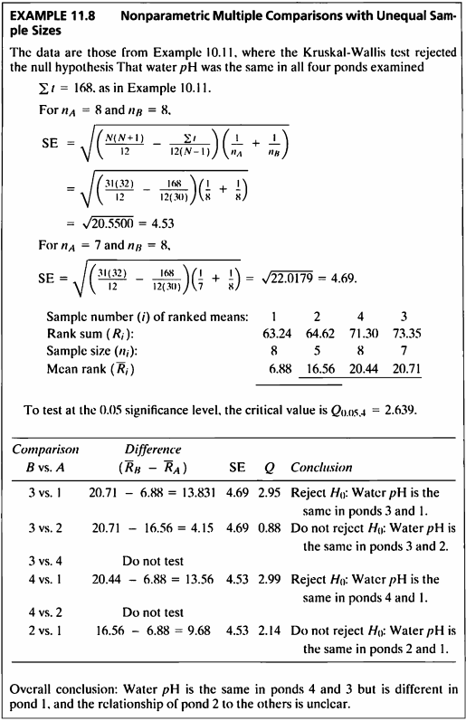

- 이 예제는 EXAMPLE 10.11를 Dunn test를 이용하여 비모수적 다중비교를 하는 문제이다.
- 위 Nemenyi test와 비슷한 방법이지만 표본크기가 다른 데이터이므로 그룹간의 차이가 어떤 그룹간에 있는지 Dunn test를 사용하였다.

> Dunn test

```r
ex11_8 <- read_excel(path = 'C:/git_blog/study/data/ch10/data_chap10.xls',sheet = 'exam10_11')
kwAllPairsDunnTest(ex11_8$ph, ex11_8$pond, p.adjust.method = "bonferroni")
```

```
##   1     2     3
## 2 0.196 -     -
## 3 0.019 1.000 -
## 4 0.017 1.000 1.000
```

- 검정 결과 그룹 [1,3], 그룹 [1,4]은 서로 다른 분포를 가지고 있음을 확인할 수 있다.

## 0.10 EXAMPLE 11.9

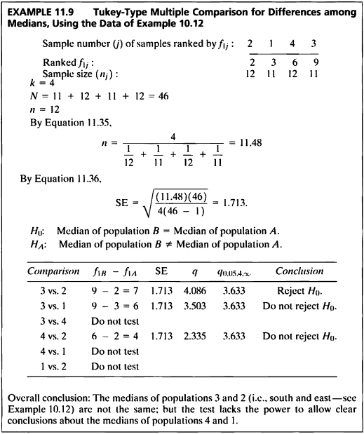

- 이 예제는 EXAMPLE 10.12를 Tukey-Type multiple comparison를 이용하여 그룹간 중앙값의 차이가 있는지 다중비교하는 문제이다.

```r
ex11_9 <- read_excel(path = 'C:/git_blog/study/data/ch10/data_chap10.xls',sheet = 'exam10_12')
median(ex11_9$height)
```

```
## [1] 7.9
```

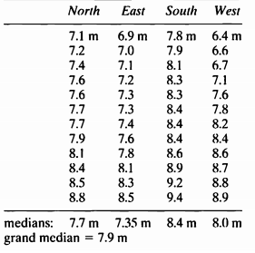

- 중앙값은 7.9 값이 나왔으며, 7.9보다 큰 첫번째 수인 8.1보다 큰 수를 빈도로 잡아 North:3, East:2, South:9, West:6 값이 나온다.

```r
s.size <- c(11,12,11,12)
N <- 46 ; n <- round(4/sum(1/s.size),2) ; se <- round(sqrt(n*N /(4*(N-1))),3)
freq <- c()
for (i in 1:4) {
  freq[i] = length(which(ex11_9$height[ex11_9$side==i] > 8.1))
}
diff <- c(freq[3]-freq[2],freq[3]-freq[1],freq[4]-freq[2])

table <- data.frame(Comparison=c("3 vs. 2", "3 vs. 1", "4 vs. 2"), Difference=diff, SE=se, q= round(diff/se,3), Critical_Value = 3.633)
table %>%
  kbl(caption = "") %>%
  kable_classic(full_width = F, html_font = "Cambria")
```

| Comparison | Difference | SE | q | Critical_Value |
| --- | --- | --- | --- | --- |
| 3 vs. 2 | 7 | 1.713 | 4.086 | 3.633 |
| 3 vs. 1 | 6 | 1.713 | 3.503 | 3.633 |
| 4 vs. 2 | 4 | 1.713 | 2.335 | 3.633 |

-4개의 그룹을 두 그룹 씩 중앙값을 통해 차이 검정을 실시하였다.  
- 귀무가설은 ‘두 모집단의 중앙값은 동일하다.’, 대립가설은 ‘두 모집단의 중앙값은 동일하지 않다.’ 이며,  
q 통계량이 임계값 3.633 보다 클 경우 귀무가설을 기각한다.  
- 검정 결과 그룹 3과 2를 비교했을 때, q 통계량이 임계값보다 크므로 귀무가설을 기각하여 3번과 2번 모집단의 중앙값이 서로 동일하지 않음을 알 수 있다.

## 0.11 EXAMPLE 11.10

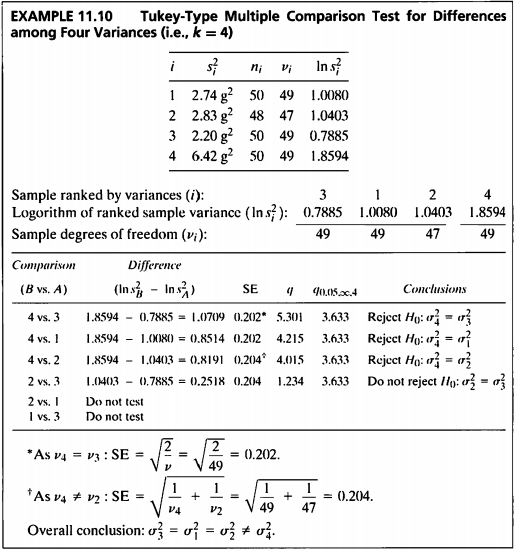

- 이 예제는 분산이 동일하지 않은 결과에 대한 다중비교를 하는 문제이다.

```r
var <- c(2.74,2.83,2.20,6.42) ; n<- c(50,48,50,50) ; v <- n-1 ; treat <- c("1","2","3","4")
q_crit <- 3.633 ; Difference = round(log(c(var[4]/var[3], var[4]/var[1],var[4]/var[2], var[2]/var[3])),4)
SE = round(sqrt(c(1/v[4]+1/v[3], 1/v[4]+1/v[1],1/v[4]+1/v[2],1/v[2]+1/v[3])),3)
table <- data.frame(Comparison=c("4 vs. 3","4 vs. 1","4 vs. 2","2 vs. 3"), Difference,SE, q = round(Difference/SE,3), Critical_Value=q_crit)

table %>%
  kbl(caption = "") %>%
  kable_classic(full_width = F, html_font = "Cambria")
```

| Comparison | Difference | SE | q | Critical_Value |
| --- | --- | --- | --- | --- |
| 4 vs. 3 | 1.0710 | 0.202 | 5.302 | 3.633 |
| 4 vs. 1 | 0.8515 | 0.202 | 4.215 | 3.633 |
| 4 vs. 2 | 0.8191 | 0.204 | 4.015 | 3.633 |
| 2 vs. 3 | 0.2518 | 0.204 | 1.234 | 3.633 |

- 4개의 그룹을 두 그룹 씩 등분산 검정을 실시하였다.
- 귀무가설은 ‘두 그룹의 모분산은 동일하다.’, 대립가설은 ‘두 그룹의 모분산은 동일하지 않다.’ 이며,  
  검정 결과 q 통계량이 임계값 3.633 보다 클 경우 귀무가설을 기각한다.
- 검정 결과 그룹 4는 나머지 그룹 전체와 서로 모분산이 동일하지 않으며, 그 외 그룹들의 모분산들은 서로 동일함을 알 수 있다.